# Lab4

Amit Yaron and Akiva Finkelstein

6/20/2021

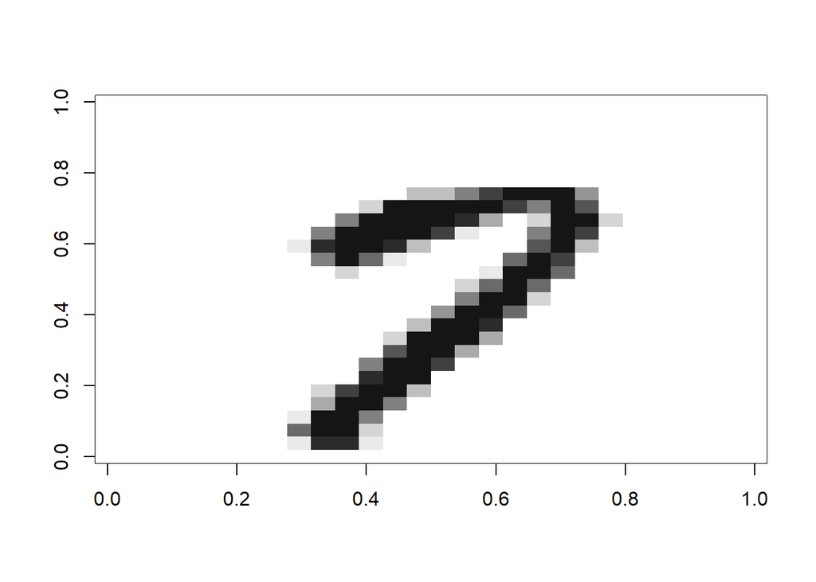

#Q1.1: ##### WE choose to compare two methods: Random Forst and Logistic regression we choose run Random Forest trees on the train data. first we use regression tree on the training set then we use bagging to Reduces the variance in fitting.

The second method we use is logistic regression We assume a linear relationship between the predictor variables and the log-odds (also called logit) of the event that Y=1(image is 3).

#for both model we pick a threshold of .5, since we assume the errors are treated symetrically i.e FN and FP are treated the same.

#Random forest

```
## ntree      OOB      1      2
##     1:  10.00%  9.43% 10.59%
##     2:   9.00%  8.20%  9.84%
##     3:   9.08%  8.10% 10.10%
##     4:   9.05%  8.00% 10.16%
##     5:   8.36%  7.50%  9.26%
##     6:   7.74%  6.96%  8.54%
##     7:   7.20%  6.80%  7.62%
##     8:   6.41%  6.12%  6.72%
##     9:   6.09%  5.85%  6.34%
##    10:   5.73%  5.72%  5.74%
##    11:   5.10%  5.31%  4.89%
##    12:   4.54%  4.81%  4.26%
##    13:   4.33%  4.74%  3.90%
##    14:   4.35%  4.65%  4.05%
```

[output cut: 86 more lines]

#logistic regression

#Q1.2 confusion matrix

Confusion matrix for the glm model train set

|  | True_Pos | False_pos | False_Neg | True_neg | Precision | recall | False_Pos_rate |
| --- | --- | --- | --- | --- | --- | --- | --- |
| Freq | 0 | 2045 | 1955 | 0 | 0 | 0 | 1 |

Confusion matrix for the glm model, test set

|  | True_Pos | False_pos | False_Neg | True_neg | Precision | recall | False_Pos_rate |
| --- | --- | --- | --- | --- | --- | --- | --- |
| Freq | 99 | 911 | 869 | 105 | 0.0980198 | 0.1022727 | 0.8966535 |

Confusion matrix for the random forest model,train set

|  | True_Pos | False_pos | False_Neg | True_neg | Precision | recall | False_Pos_rate |
| --- | --- | --- | --- | --- | --- | --- | --- |
| Freq | 1989 | 56 | 25 | 1930 | 0.9726161 | 0.9875869 | 0.0281974 |

Confusion matrix for the random forest model, test set

|  | True_Pos | False_pos | False_Neg | True_neg | Precision | recall | False_Pos_rate |
| --- | --- | --- | --- | --- | --- | --- | --- |
| Freq | 987 | 23 | 9 | 965 | 0.9772277 | 0.9909639 | 0.0232794 |

#We can see from the tables above that the random forest model is a better predictor for this data set. It was correct more and mistaken less. We can see that the logistic regression on the training set has only mistakes and no correct predictions. For the random forest we can see that both the test and the training set are not so fr apart so we assume the model was not over fitted.

#Q1.3 Draw ROC

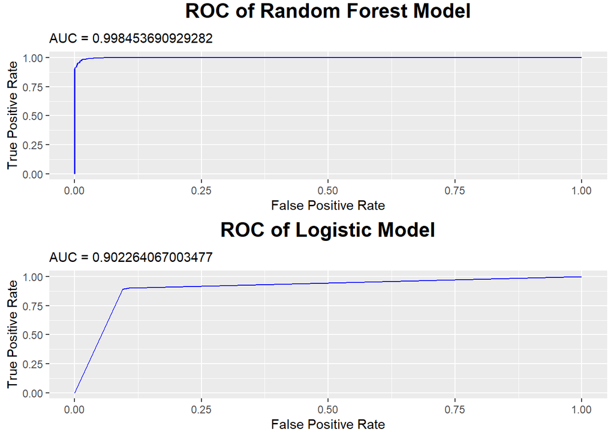

#From the plots above we can see that the random forest model is a better model beacause it has a higher auc level.

#Q1.4

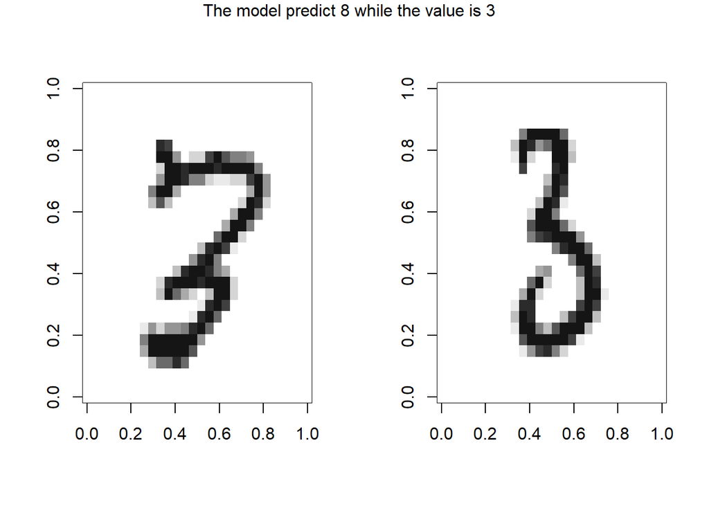

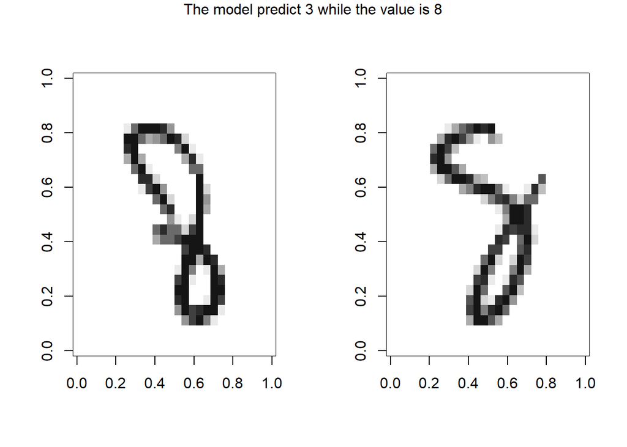

#Q_1.5 #WE think that the random forest will predict the image well since random forest classifies based on the differences in the values and not based on the values. While the logistic regression will not predict well since is based on the accrual values. So if you switch from black to white it will not be able to predict.